```python
import numpy as np
```

# Q1: Import matplotlib library

```python
# write your code here ^_^
import matplotlib.pyplot as plt
```

# Q2: Create a one line chart using two arrays. The first array represents x and the second array represents y

| x | y |
| --- | --- |
| 1 | 1 |
| 2 | 2 |
| 3 | 3 |
| 4 | 5 |
| 5 | 8 |
| 6 | 13 |
| 7 | 20 |

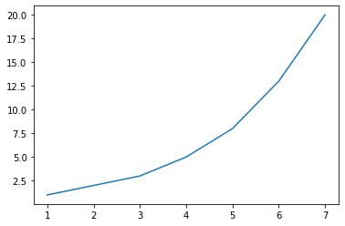

```python
# write your code here ^_^
x=[1,2, 3, 4, 5,6,7];
y=[1,2,3,5,8,13,20];
plt.plot(x, y);
```

# Q3: Create a two lines chart using the same previous arrays.

But this time:

- Mark each point with a circle.
- Use dashed lines.
- Set the size of the marker (circle) to size 10.
- Set the width of the line to 3.
- Add legends. 'Normal' for array x and 'Fast' for array y.

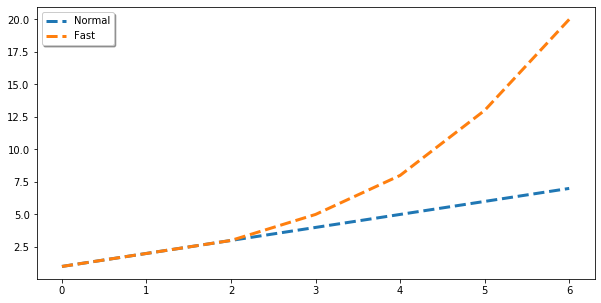

```python
# write your code here ^_^
plt.figure(figsize = [10,5])
x=[1,2, 3, 4, 5,6,7];
y=[1,2,3,5,8,13,20];
plt.plot(x, linestyle = '--', linewidth = 3);
plt.plot(y, linestyle = '--', linewidth = 3);

plt.legend(['Normal','Fast'], shadow = True, loc = 0);
```

# Q4: Display multiple linear charts in one row using the charts given below.

- Give each chart a title
- Add a super title 'my data visulaization assignment'.

```python
#super title = my data visulaization assignment

#title = First Chart
x_plot1 = np.array([1, 2, 3, 4, 5, 6, 7])
y_plot1 = np.array([1, 1, 2, 3, 5, 8, 13])

#title = Second Chart
x_plot2 = np.array([0, 1, 2, 3, 4, 5, 6])
y_plot2 = np.array([2, 4, 6, 8, 10, 12, 14])

#title = Third Chart
x_plot3 = np.array([0, 1, 3, 4])
y_plot3 = np.array([4, 6, 3, 4])
```

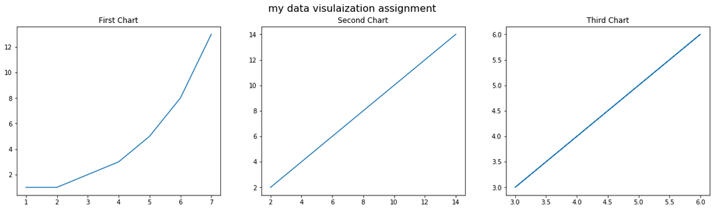

```python
# write your code here ^_^
plt.figure(figsize=[20,5])
plt.suptitle('my data visulaization assignment',fontsize = 16)

#1
plt.subplot(1,3,1)
#title = First Chart
x_plot1 = np.array([1, 2, 3, 4, 5, 6, 7])
y_plot1 = np.array([1, 1, 2, 3, 5, 8, 13])
plt.title('First Chart')
plt.plot(x_plot1,y_plot1 );

#2
plt.subplot(1,3,2)
#title = Second Chart
x_plot2 = np.array([0, 1, 2, 3, 4, 5, 6])
y_plot2 = np.array([2, 4, 6, 8, 10, 12, 14])
plt.title('Second Chart')
plt.plot(y_plot2,y_plot2);

#3
plt.subplot(1,3,3)
#title = Third Chart
x_plot3 = np.array([0, 1, 3, 4])
y_plot3 = np.array([4, 6, 3, 4])
plt.title('Third Chart')
plt.plot(y_plot3,y_plot3);
```

# Q5: Define an array that has a values of your top three TV series and define another array to hold the rating of the three TV series out of 10. Create a bar chart using the two arrays

- Set a new color for the bars.
- Change the width of the bars to width 0.5.

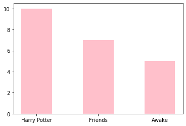

```python
# write your code here ^_^
x = np.array(["Harry Potter", "Friends", "Awake"])
y = np.array([10, 7, 5])
plt.bar(x, y,width=0.5,color='pink');
```

# Q6: Create a scatter plot using two arrays. The first array represents carAge and the second array represents carSpeed, set a specific color for each dot by using an array of different colors and add labels for the plot

| carAge | carSpeed |
| --- | --- |
| 5 | 99 |
| 7 | 86 |
| 8 | 87 |
| 7 | 88 |
| 2 | 111 |
| 17 | 86 |
| 2 | 103 |
| 9 | 87 |
| 4 | 94 |
| 11 | 78 |

- Set a new color for each dot by using an array of different colors.
- Change the size of the dots to size 350.
- Add labels for x-axis and y-axis.
- Adjust the transparency of the dots with the alpha argument. let the alpha value be 0.4

[figure not shown]

```python
# write your code here ^_^
import itertools

x=[5,7,8,7,2,17,2,9,4,11]
y=[99,86,87,88,111,86,103,87,94,87]
colors = itertools.cycle(["r", "b", "g"])
for y in ys:
    plt.scatter(x, y,s=350,alpha=0.4, color=next(colors))

plt.xlabel('Days');
plt.ylabel('Sales');
```

# Q7: Create a pie chart using two arrays. The first array represents python_libraries and the second array represents your skills out of 10 at each library

| python_libraries |
| --- |
| NumPy |
| Pandas |
| Matplotlib |
| Seaborn |
| Plotly |
| Scikit-learn |

- Set a new color for each wedge by using an array of different colors.
- Pull your favorite library wedge 0.3 from the center of the pie.
- Add a shadow to the pie chart

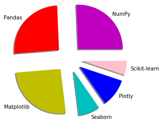

```python
# write your code here ^_^
x=["NumPy","Pandas","Matplotlib","Seaborn","Plotly","Scikit-learn"]
y=[10,10,10,3,4,2]

colors = ['m','r','y','c','b','pink'];
plt.pie(y, labels=x,shadow=True, explode = [.3,.3,.3,.3,.3,.3],colors=colors);
```

# Q8: Create a histogram with 250 values and 15 bars

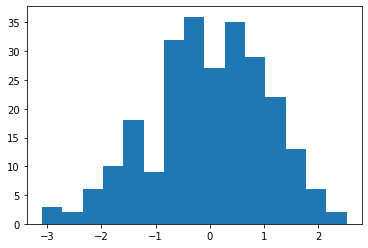

```python
# write your code here ^_^
x = np.random.randn(250)
plt.hist(x,15);
```